# Stratification of the Late-Middle-Age Moravian nobility according to dowry, replication material

Michael Skvrnak

June 22, 2016

## Loading data

```r
library(magrittr)

vena_basic <- read.csv("vena_basic.csv",
                       stringsAsFactors = FALSE)

vena_basic$sum <- as.numeric(vena_basic$sum)
head(vena_basic)
```

```
##   ID  rok idd pos idd.1 pau  sum vec va addtrans
## 1  1 1408  14   0     1   0  600   0  0        0
## 2  2 1417  14   0     1   0  400   0  0        2
## 3  3 1385  12   0     1   0  600   0  0        0
## 4  4 1349   ?   ?     2   0   NA   0  0        0
## 5  5 1390  32   0     3   0 1000   0  0        0
## 6  6 1406  15   0     3   0  800   1  0        0
```

### Description of the data:

Variables:

- **ID** - identification number of the dower
- **rok** - year of the record
- **idd** - identification number of the dynasty
- **pos** - status of the recipient (NA - unknown, 0 - high nobility, 1 - pauperized high nobility, 2 - lower nobility)
- **idd.1**
- **pau** - status of the donor (0 - high nobility, 1 - pauperized high nobility)
- **sum** - the value of the dower
- **vec** - widower (1)/non-widower(0)
- **va** - widow (1)/non-widow(0)
- **addtrans** - no changes to the dower (0) / adding to the dower (1) / transfer of the dower to different assets (2)

## Ratio between dower and dowry

```r
library(ggplot2)

# complete observations only
dowry <- c(200, 1000, 250, 200, 350, 600, 100, 200, 200)
dower <- c(260, 1000, 250, 500, 500, 1000, 150, 200, 500)
coefs <- dower/dowry

#mean(coefs)
summary(coefs)
```

```
##    Min. 1st Qu.  Median    Mean 3rd Qu.    Max.
##   1.000   1.000   1.429   1.544   1.667   2.500
```

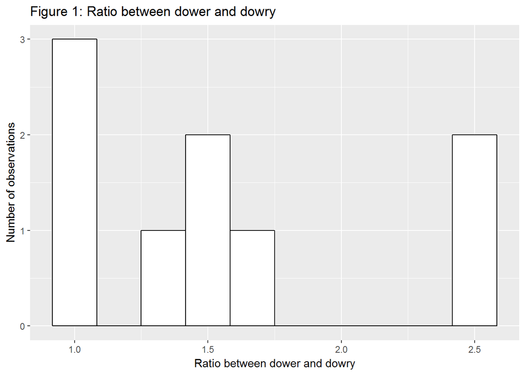

```r
df <- data.frame(dowry = dowry, dower = dower, coefs = coefs)

ggplot(data = df, aes(x = coefs)) +
  geom_histogram(bins = 10,
                 color = "black",
                 fill = "white") +
  xlab("Ratio between dower and dowry") +
  ylab("Number of observations") +
  ggtitle("Figure 1: Ratio between dower and dowry")
```

*“According to Vsehrd, the dower should be 2.5 times higher than the dowry”*

That does not hold true. Although we know both the values of dower and dowry only in nine cases, the dower reached the ratio of 2.5 only in 2 of them. In the rest of the observations, it did not reach even 2 and the most common ratio was 1.

## EDA: Dowers in time

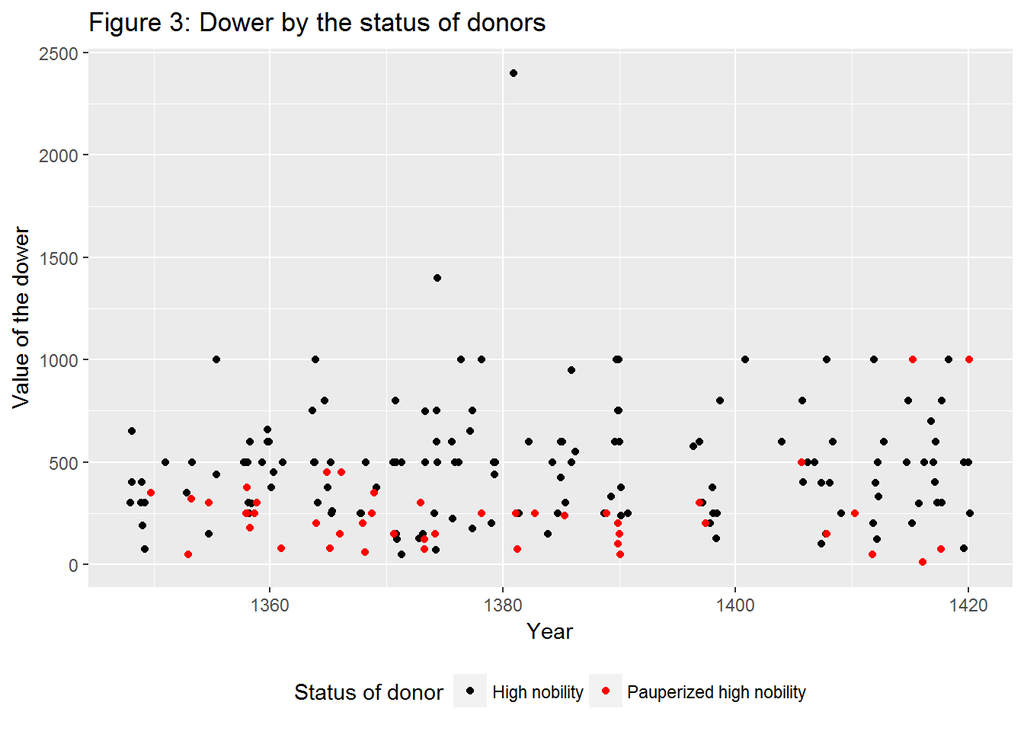

```r
dar <- ggplot(data = vena_basic, aes(x = rok, y = sum, color = factor(pau))) + geom_jitter() +
  labs(x = "Year", y = "Value of the dower", color = "Status of donor") + theme(legend.position = "bottom") +
  scale_color_manual(values = c("black", "red"),
                     labels = c("High nobility",
                              "Pauperized high nobility")) +
  ggtitle("Figure 3: Dower by the status of donors")
dar
```

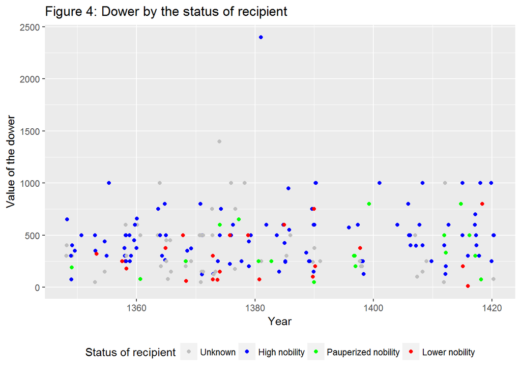

```r
prijem <- ggplot(data = vena_basic, aes(x = rok, y = sum, color = factor(pos)))
prijem + geom_jitter() +
  labs(x = "Year", y = "Value of the dower",
       color = "Status of recipient") +
  theme(legend.position = "bottom") +
  scale_color_manual(values = c("grey", "blue", "green", "red"),
                     labels = c( "Unknown", "High nobility",
                               "Pauperized nobility",
                               "Lower nobility")) +
  ggtitle("Figure 4: Dower by the status of recipient")
```

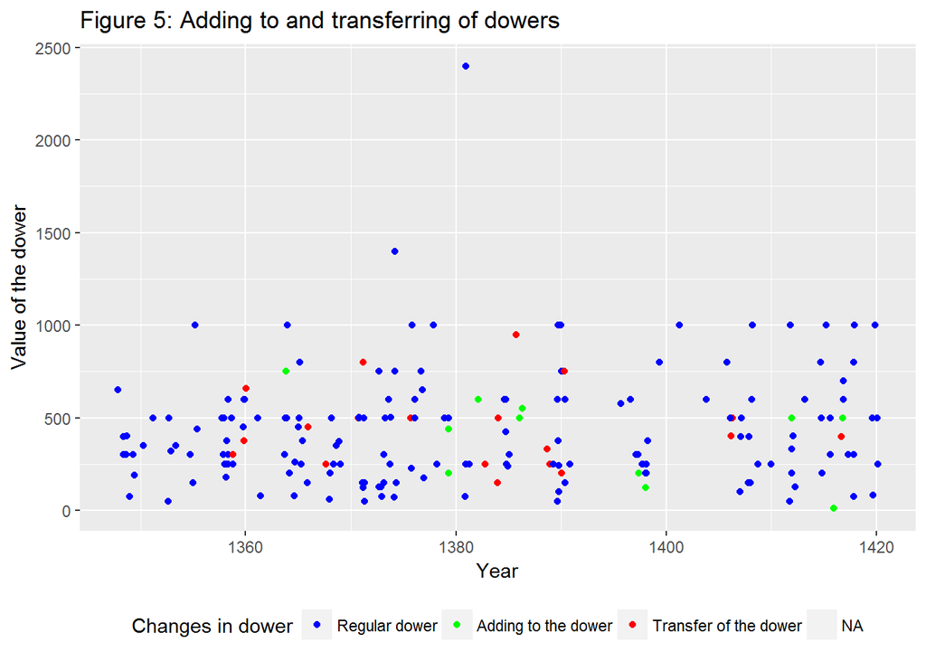

```r
vena_basic$addtrans[vena_basic$addtrans == "?"] <- NA

trans <- ggplot(data = vena_basic,
                aes(x = rok, y = sum,
                    color = factor(addtrans)))
trans + geom_jitter() +
  labs(x = "Year", y = "Value of the dower",
       color = "Changes in dower") +
  theme(legend.position = "bottom") +
  scale_color_manual(values = c("blue", "green", "red"),
                     labels = c("Regular dower",
                              "Adding to the dower",
                              "Transfer of the dower")) +
  ggtitle("Figure 5: Adding to and transferring of dowers")
```

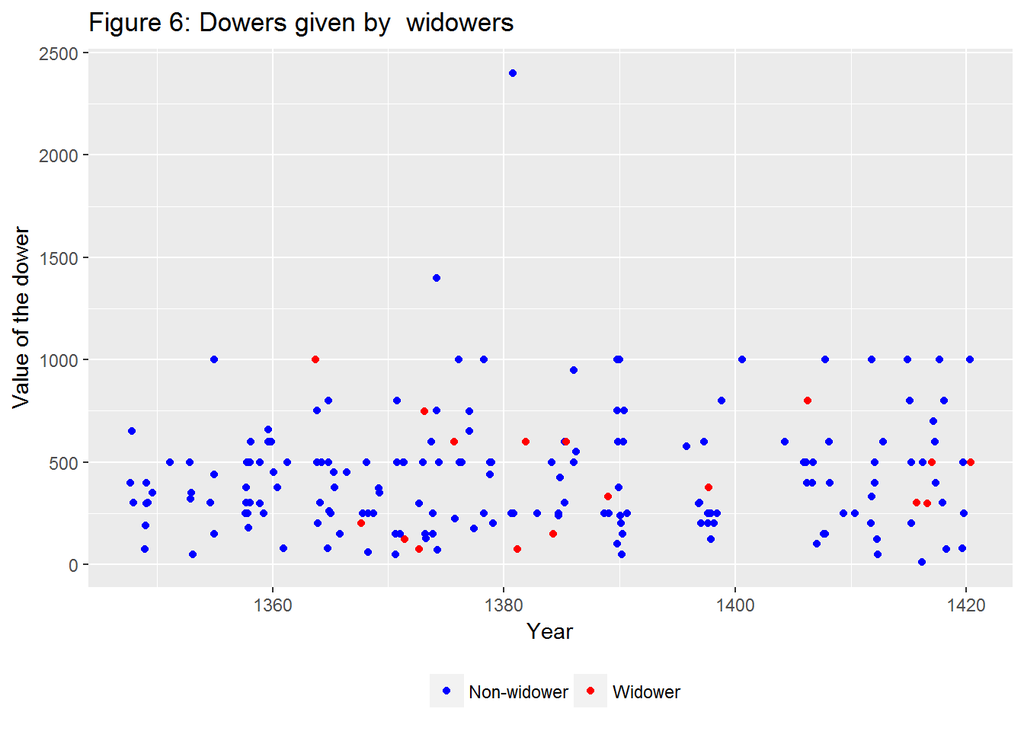

```r
vdovec <- ggplot(data = vena_basic,
                 aes(x = rok, y = sum, color = factor(vec)))
vdovec + geom_jitter() +
  labs(x = "Year", y = "Value of the dower", color = "") +
  theme(legend.position = "bottom") +
  scale_color_manual(values = c("blue", "red"),
                     labels = c("Non-widower", "Widower")) +
  ggtitle("Figure 6: Dowers given by  widowers")
```

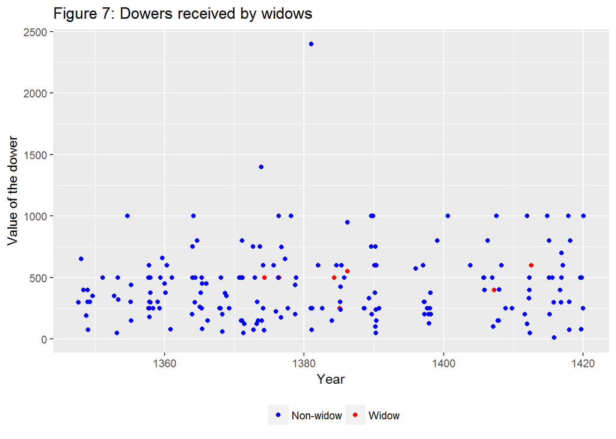

```r
vdovy <- ggplot(data = vena_basic,
                aes(x = rok, y = sum, color = factor(va)))
vdovy + geom_jitter() +
  labs(x = "Year", y = "Value of the dower", color = "") +
  theme(legend.position = "bottom") +
  scale_color_manual(values = c("blue", "red"),
                     labels = c("Non-widow", "Widow")) +
  ggtitle("Figure 7: Dowers received by widows")
```

## Charts 2: Size of the dower

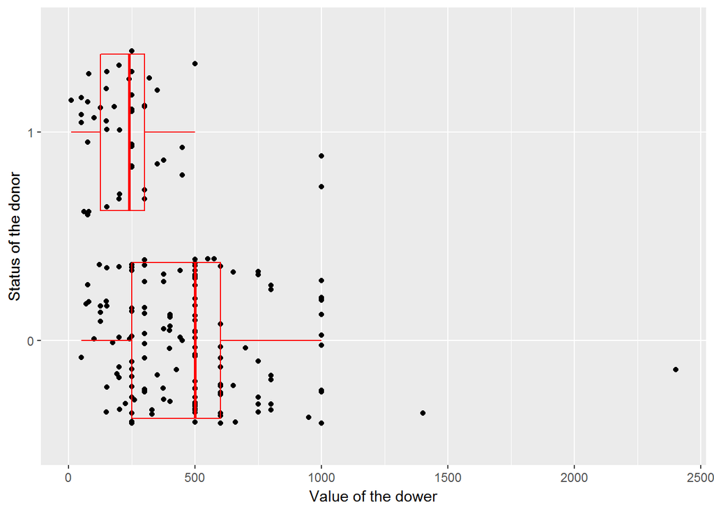

```r
#plot <- ggplot(data=vena_basic, aes(x=sum, y=pau))
#plot + geom_point()

# Size of the dower by the status of the donor
plot2 <- ggplot(data = vena_basic, aes(x = factor(pau), y = sum))
plot2 + geom_jitter() +
  geom_boxplot(color = "red", fill = NA, outlier.colour = NA) +
  coord_flip() +
  labs(y = "Value of the dower", x = "Status of the donor")
```

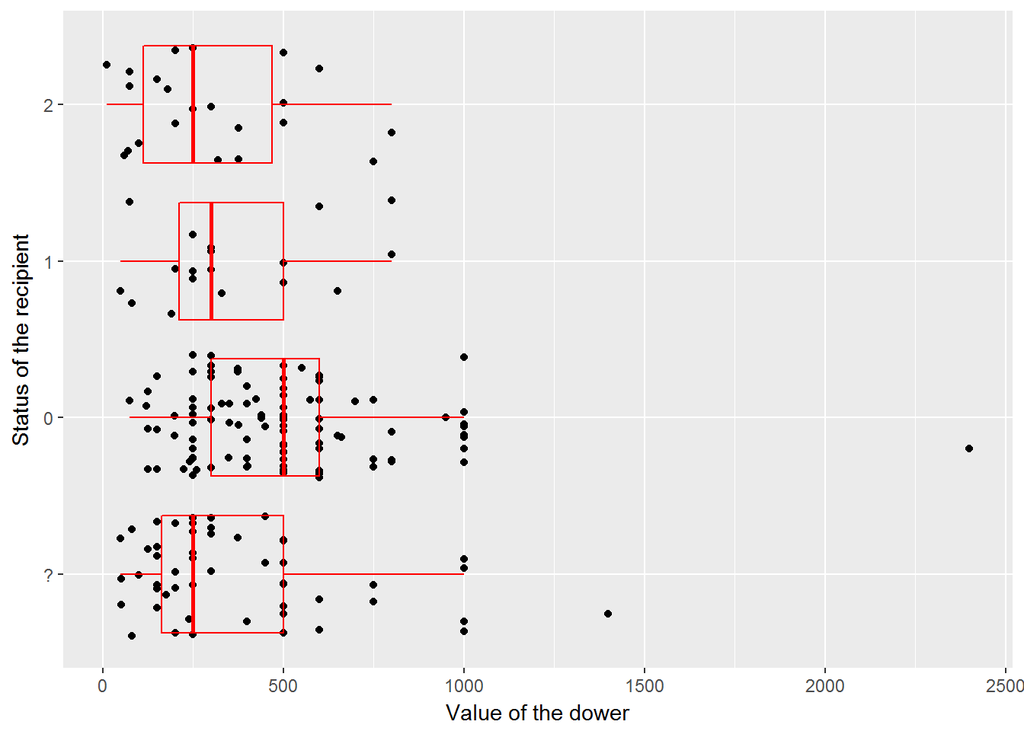

```r
# Size of the dower by the status of the recipient
plot3 <- ggplot(data = vena_basic, aes(x = factor(pos), y = sum))
plot3 + geom_jitter() +
  geom_boxplot(color = "red", fill = NA, outlier.colour = NA) +
  coord_flip() +
  labs(y = "Value of the dower", x = "Status of the recipient")
```

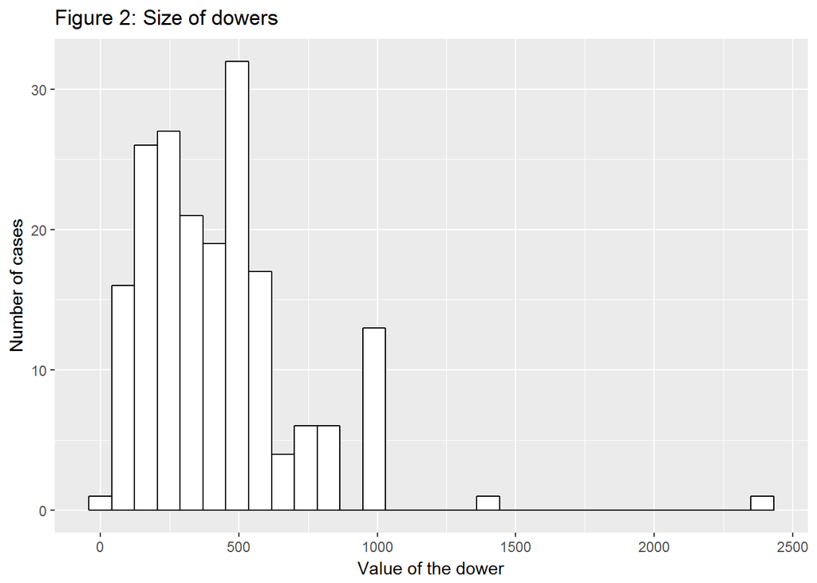

```r
hist2 <- ggplot(data = vena_basic, aes(x = sum))
hist2 + geom_histogram(color = "black", fill = "white") +
  labs(x = "Value of the dower", y = "Number of cases") +
  ggtitle("Figure 2: Size of dowers")
```

```r
summary(vena_basic$sum)
```

```
##    Min. 1st Qu.  Median    Mean 3rd Qu.    Max.    NA's
##    10.0   250.0   375.0   428.1   537.5  2400.0      52
```

## Correlations

```r
# Correlation between dower and status of the donors
cor(vena_basic$sum[!is.na(vena_basic$sum == TRUE)],
    vena_basic$pau[!is.na(vena_basic$sum == TRUE)],
    method = "pearson")
```

```
## [1] -0.345052
```

```r
# Correlation between dower and status of the recipient
# (excluding the unknown dynasties)
kor2 <- vena_basic[vena_basic$pos != "?", ]
kor2$pos <- as.numeric(kor2$pos)
cor(kor2$pos[!is.na(kor2$sum == TRUE)],
    kor2$sum[!is.na(kor2$sum == TRUE)],
    method = "spearman")
```

```
## [1] -0.2969235
```

The correlation coefficient indicate that both the status of the donor and the recipient influenced the size of the dower. In particular, higher status led to higher dower.

```r
# Who married who (absolute numbers)
table(vena_basic$pau, vena_basic$pos)
```

```
##
##       ?   0   1   2
##   0  49 110  15  16
##   1  14  18   9  11
```

```r
# Who married who (row percent)
prop.table(table(vena_basic$pau, vena_basic$pos), 1)
```

```
##
##              ?          0          1          2
##   0 0.25789474 0.57894737 0.07894737 0.08421053
##   1 0.26923077 0.34615385 0.17307692 0.21153846
```

The tables show that the groom from high nobility married predominantly brides from high nobility. However, grooms from pauperized dynasties had higher chances to marry a bride from higher nobility than the other way around.

## The regression model of dower

Hypotheses:

H1: Higher the status of the donor, the higher the value of the dower.

H2: Higher the status of the recipient, the higher the value of the dower.

H3: Widows received lower dowers than non-widows.

H4: Widowers gave lower dower than non-widowers because it is expected that they have children from previous marriage.

H5: Dowers to which were added later were lower than the rest (because they were given by young noblemen who had not much capital)

```r
# Recode the status of the recipient into two categories
## 0 = high nobility
## 1 = the rest (pauperized, lower, unknown dynasties)
vena_basic$pos[vena_basic$pos != 0] <- 1

model1 <- lm(log1p(sum) ~ pau + factor(pos), data = vena_basic)
summary(model1)
```

```
##
## Call:
## lm(formula = log1p(sum) ~ pau + factor(pos), data = vena_basic)
##
## Residuals:
##      Min       1Q   Median       3Q      Max
## -2.70397 -0.31508  0.06407  0.40895  1.63111
##
## Coefficients:
##              Estimate Std. Error t value Pr(>|t|)
## (Intercept)   6.15253    0.06905  89.101  < 2e-16 ***
## pau          -0.70580    0.11595  -6.087 6.38e-09 ***
## factor(pos)1 -0.34487    0.09868  -3.495 0.000592 ***
## ---
## Signif. codes:  0 '***' 0.001 '**' 0.01 '*' 0.05 '.' 0.1 ' ' 1
##
## Residual standard error: 0.6644 on 187 degrees of freedom
##   (52 observations deleted due to missingness)
## Multiple R-squared:  0.2455, Adjusted R-squared:  0.2374
## F-statistic: 30.42 on 2 and 187 DF,  p-value: 3.649e-12
```

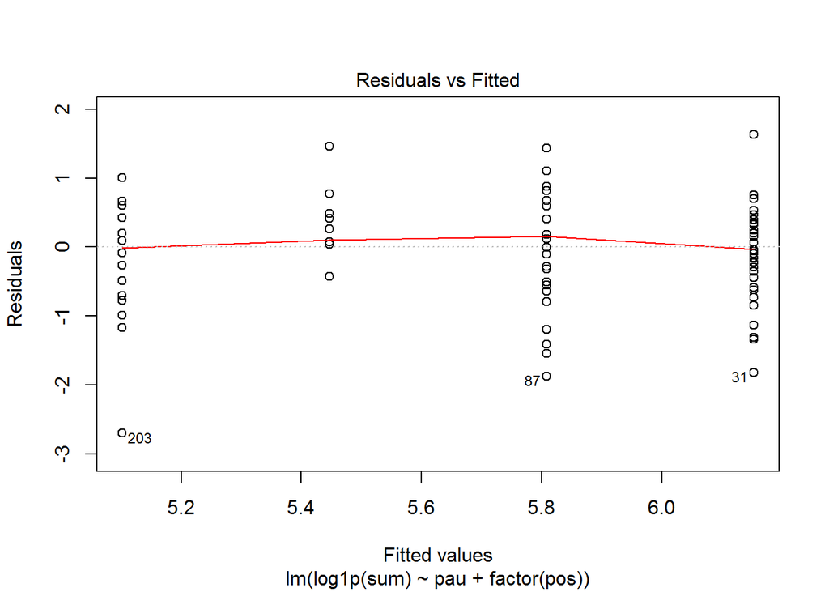

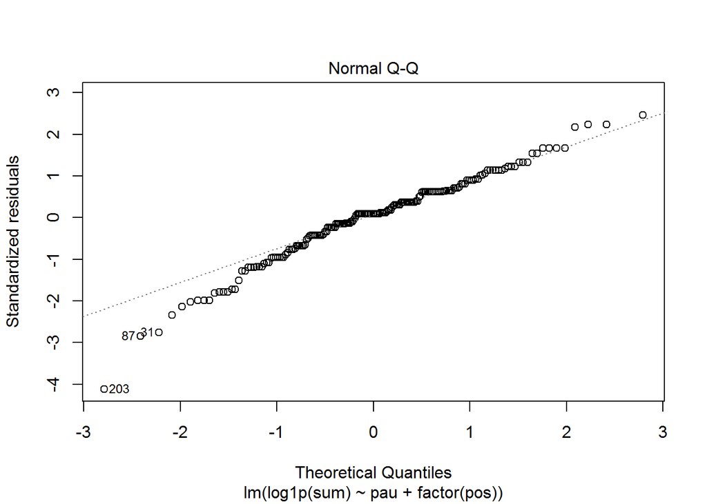

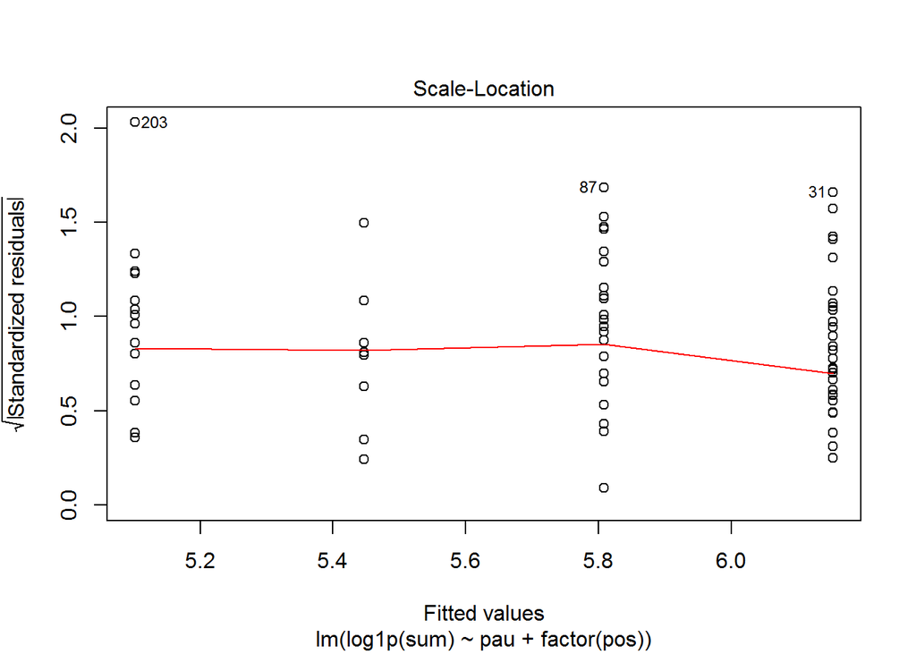

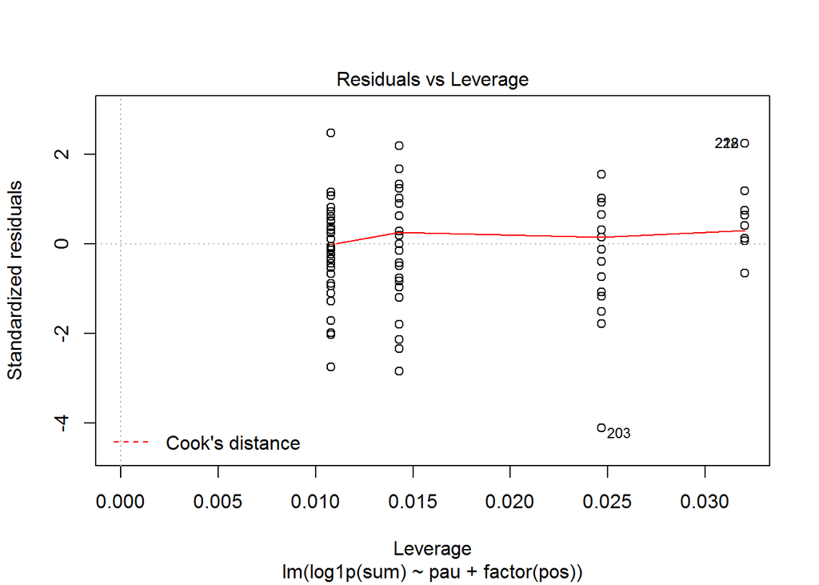

```r
plot(model1)
```

```r
model2 <- update(model1, . ~ . + va)
summary(model2)
```

```
##
## Call:
## lm(formula = log1p(sum) ~ pau + factor(pos) + va, data = vena_basic)
##
## Residuals:
##      Min       1Q   Median       3Q      Max
## -2.70355 -0.31561  0.06261  0.40874  1.62964
##
## Coefficients:
##              Estimate Std. Error t value Pr(>|t|)
## (Intercept)   6.15400    0.07244  84.958  < 2e-16 ***
## pau          -0.70643    0.11662  -6.058 7.49e-09 ***
## factor(pos)1 -0.34613    0.10062  -3.440 0.000718 ***
## va           -0.01698    0.24643  -0.069 0.945142
## ---
## Signif. codes:  0 '***' 0.001 '**' 0.01 '*' 0.05 '.' 0.1 ' ' 1
##
## Residual standard error: 0.6662 on 186 degrees of freedom
##   (52 observations deleted due to missingness)
## Multiple R-squared:  0.2455, Adjusted R-squared:  0.2333
## F-statistic: 20.17 on 3 and 186 DF,  p-value: 2.305e-11
```

```r
model3 <- update(model2, . ~ . + vec)
summary(model3)
```

```
##
## Call:
## lm(formula = log1p(sum) ~ pau + factor(pos) + va + vec, data = vena_basic)
##
## Residuals:
##      Min       1Q   Median       3Q      Max
## -2.71216 -0.30628  0.06709  0.39460  1.61333
##
## Coefficients:
##              Estimate Std. Error t value Pr(>|t|)
## (Intercept)   6.17031    0.07502  82.250  < 2e-16 ***
## pau          -0.71194    0.11689  -6.091 6.36e-09 ***
## factor(pos)1 -0.34830    0.10073  -3.458 0.000676 ***
## va           -0.03328    0.24737  -0.135 0.893112
## vec          -0.14010    0.16592  -0.844 0.399554
## ---
## Signif. codes:  0 '***' 0.001 '**' 0.01 '*' 0.05 '.' 0.1 ' ' 1
##
## Residual standard error: 0.6667 on 185 degrees of freedom
##   (52 observations deleted due to missingness)
## Multiple R-squared:  0.2484, Adjusted R-squared:  0.2321
## F-statistic: 15.29 on 4 and 185 DF,  p-value: 8.106e-11
```

```r
## Recode the addtrans variables so that:
## 1 = adding to the dower
## 0 = the rest (no change, transfer of the dower)
vena_basic$addtrans[vena_basic$addtrans != 1] <- 0

model4 <- update(model3, . ~ . + factor(addtrans))
summary(model4)
```

```
##
## Call:
## lm(formula = log1p(sum) ~ pau + factor(pos) + va + vec + factor(addtrans),
##     data = vena_basic)
##
## Residuals:
##      Min       1Q   Median       3Q      Max
## -2.44508 -0.32164  0.04503  0.40602  1.59662
##
## Coefficients:
##                   Estimate Std. Error t value Pr(>|t|)
## (Intercept)        6.18702    0.07591  81.503  < 2e-16 ***
## pau               -0.71389    0.11666  -6.120 5.52e-09 ***
## factor(pos)1      -0.35369    0.10060  -3.516 0.000552 ***
## va                -0.01544    0.24723  -0.062 0.950276
## vec               -0.12337    0.16605  -0.743 0.458451
## factor(addtrans)1 -0.27646    0.20791  -1.330 0.185250
## ---
## Signif. codes:  0 '***' 0.001 '**' 0.01 '*' 0.05 '.' 0.1 ' ' 1
##
## Residual standard error: 0.6653 on 184 degrees of freedom
##   (52 observations deleted due to missingness)
## Multiple R-squared:  0.2555, Adjusted R-squared:  0.2353
## F-statistic: 12.63 on 5 and 184 DF,  p-value: 1.483e-10
```